# Optimal Transport for Counterfactual Estimation: A Method for Causal Inference

Online Appendix: simulations (multivariate case)

Authors

Arthur Charpentier

Emmanuel Flachaire

Ewen Gallic

In this notebook, we compute the SCATE at three different points: $\boldsymbol{x}=(2500,60)$, $\boldsymbol{x}=(4200,60)$, and $\boldsymbol{x}=(2500,20)$. At each point, we will estimate the SCATE using a GAM model with Gaussian transport depending on the number of observations used to train the models.

# 1 Data

To illustrate the methods, we rely on the *Linked Birth/Infant Death Cohort Data* (2013 cohort). The CSV files for the 2013 cohort were downloaded from the NBER collection of [Birth Cohort Linked Birth and Infant Death Data](http://www.cdc.gov/nchs/linked.htm) of the [National Vital Statistics System](http://www.cdc.gov/nchs/nvss.htm) of the [National Center for Health Statistics](http://www.cdc.gov/nchs/nvss.htm), on the [NBER](https://www.nber.org/research/data/linked-birthinfant-death-cohort-data) website. We formated the data (see ./births_stats.html).

Let us load the birth data.

```r
library(tidyverse)
load("../data/births.RData")
```

Then, we can only keep a subsample of variables to illustrate the method.

```r
base <-
  births %>%
  mutate(
    black_mother = mracerec == "Black",
    nonnatural_delivery = rdmeth_rec != "Vaginal"
  ) %>%
  select(
    sex, dbwt, cig_rec, wtgain,
    black_mother, nonnatural_delivery,
    mracerec, rdmeth_rec
  ) %>%
  mutate(
    cig_rec = replace_na(cig_rec, "Unknown or not stated"),
    black_mother = ifelse(black_mother, yes = "Yes", no = "No"),
    is_girl = ifelse(sex == "Female", yes = "Yes", no = "No")
  ) %>%
  labelled::set_variable_labels(
    black_mother = "Is the mother Black?",
    is_girl = "Is the newborn a girl?",
    nonnatural_delivery = "Is the delivery method non-natural?"
  ) %>%
  rename(birth_weight = dbwt)
base
```

```
# A tibble: 3,940,764 × 9
   sex    birth_weight cig_rec wtgain black_mo…¹ nonna…² mrace…³ rdmet…⁴ is_girl
   <fct>         <dbl> <fct>    <dbl> <chr>      <lgl>   <fct>   <fct>   <chr>
 1 Male           3017 No           1 No         FALSE   "White" Vaginal No
 2 Female         3367 No          18 No         FALSE   "White" Vaginal Yes
 3 Male           4409 No          36 No         FALSE   "White" Vaginal No
 4 Male           4047 No          25 No         FALSE   "White" Vaginal No
 5 Male           3119 Yes          0 No         FALSE   "Ameri… Vaginal No
 6 Female         4295 Yes         34 No         FALSE   "White" Vaginal Yes
 7 Male           3160 No          47 No         FALSE   "Ameri… Vaginal No
 8 Male           3711 No          39 No         FALSE   "White" Vaginal No
 9 Male           3430 No          NA No         FALSE   "White" Vaginal No
10 Female         3772 No          36 No         FALSE   "White" Vaginal Yes
# … with 3,940,754 more rows, and abbreviated variable names ¹black_mother,
#   ²nonnatural_delivery, ³mracerec, ⁴rdmeth_rec
```

The variables that were kept are the following:

- `sex`: sex of the newborn
- `birth_weight`: Birth Weight (in Grams)
- `cig_rec`: mother smokes cigarettes
- `wtgain`: mother weight gain
- `mracerec`: mother’s race
- `black_mother`: is mother black?
- `rdmeth_rec`: delivery method
- `nonnatural_delivery`: is the delivery method non-natural?

Then, let us discard individuals with missing values.

```r
base <-
  base %>%
  filter(
    !is.na(birth_weight),
    !is.na(wtgain),
    !is.na(nonnatural_delivery),
    !is.na(black_mother)
  )
```

Let us define some colours for later use:

```r
library(wesanderson)
colr1 <- wes_palette("Darjeeling1")
colr2 <- wes_palette("Darjeeling2")
couleur1 <- colr1[2]
couleur2 <- colr1[4]
couleur3 <- colr2[2]

coul1 <- "#882255"
coul2 <- "#DDCC77"
```

We need to load some packages.

```r
library(car)
library(transport)
library(splines)
library(mgcv)
library(expm)
library(tidyverse)
```

Let us define the same functions as that used in reproduction_multivariate.html.

# 2 Functions

## 2.1 Models

Let us estimate $\color{couleur1}{\widehat{m}_0}$ and $\color{couleur2}{\widehat{m}_1}$ with a logistic GAM model (cubic spline first, then with more knots and degrees). To that end, we can define a function that will estimate both models and return them within a list.

```r
library(splines)

#' Returns $\hat{m}_0()$ and $\hat{m}_1()$, using GAM
#' @param target name of the target variable
#' @param treatment_name name of the treatment variable (column in `data`)
#' @param x_m_names names of the mediator variable
#' @param data data frame with the observations
#' @param treatment_0 value for non treated
#' @param treatment_1 value for treated
#' @param df degrees of freedom (in the `bs()` function, deefault to `df=3`)
models_spline <- function(target, treatment_name, x_m_names, data, treatment_0, treatment_1, df = 3){

  # \hat{m}_0()
  formula_glm <- paste0(target, "~", paste0("bs(", x_m_names, ", df = ",df, ")", collapse = " + "))
  reg_0 <- bquote(
    glm(formula = .(formula_glm), data=data, family = binomial,
        subset = (.(treatment_name) == .(treatment_0))),
    list(
      formula_glm = formula_glm,
      treatment_name = as.name(treatment_name),
      treatment_0 = treatment_0)
  ) %>% eval()
  # \hat{m}_1()
  reg_1 <- bquote(
    glm(formula = .(formula_glm), data=data, family = binomial,
        subset = (.(treatment_name) == .(treatment_1))),
    list(
      formula_glm = formula_glm,
      treatment_name = as.name(treatment_name),
      treatment_1 = treatment_1)
  ) %>% eval()

  list(reg_0 = reg_0, reg_1 = reg_1)
}
```

### 2.1.1 GAM (with cubic splines)

**\(T\): Smoker mother**

```r
target         <- "nonnatural_delivery"
x_m_names       <- c("wtgain", "birth_weight")
scale          <- c(1,1/100)
treatment_name <- "cig_rec"
treatment_0    <- "No"
treatment_1    <- "Yes"
```

$\color{couleur1}{\widehat{m}_0}$ and $\color{couleur2}{\widehat{m}_1}$:

```r
reg_gam_smoker <-
  models_spline(target = target,
              treatment_name = treatment_name,
              x_m_names = x_m_names,
              data = base, treatment_0 = treatment_0, treatment_1 = treatment_1, df = c(3, 3))
reg_gam_smoker_0 <- reg_gam_smoker$reg_0
reg_gam_smoker_1 <- reg_gam_smoker$reg_1
```

**\(T\): Black mother**

```r
target         <- "nonnatural_delivery"
x_m_names       <- c("wtgain", "birth_weight")
scale          <- c(1,1/100)
treatment_name <- "black_mother"
treatment_0    <- "No"
treatment_1    <- "Yes"
```

```r
reg_gam_blackm <-
  models_spline(target = target,
              treatment_name = treatment_name,
              x_m_names = x_m_names,
              data = base, treatment_0 = treatment_0, treatment_1 = treatment_1, df = c(3, 3))
reg_gam_blackm_0 <- reg_gam_blackm$reg_0
reg_gam_blackm_1 <- reg_gam_blackm$reg_1
```

**\(T\): Baby girl**

```r
target         <- "nonnatural_delivery"
x_m_names       <- c("wtgain", "birth_weight")
scale          <- c(1,1/100)
treatment_name <- "sex"
treatment_0    <- "Male"
treatment_1    <- "Female"
```

$\color{couleur1}{\widehat{m}_0}$ and $\color{couleur2}{\widehat{m}_1}$:

```r
reg_gam_sex <-
  models_spline(target = target,
              treatment_name = treatment_name,
              x_m_names = x_m_names,
              data = base, treatment_0 = treatment_0, treatment_1 = treatment_1, df = c(3, 3))
reg_gam_sex_0 <- reg_gam_sex$reg_0
reg_gam_sex_1 <- reg_gam_sex$reg_1
```

## 2.2 Prediction Functions

The prediction function for GAM:

```r
#' @param object regression model (GAM)
#' @param newdata data frame in which to look for the mediator variable used to predict the target
model_spline_predict <- function(object, newdata){
  predict(object, newdata = newdata, type="response")
}
```

## 2.3 Transport

### 2.3.1 Gaussian Assumption

The transport function can be defined as follows:

```r
#' Optimal Transport assuming Gaussian distribution for the mediator variables (helper function)
#' @return A list with the mean and variance of the mediator in each subset, and the symmetric matrix A.
#' @param target name of the target variable
#' @param x_m_names vector of names of the mediator variables
#' @param scale vector of scaling to apply to each `x_m_names` variable to transport (default to 1)
#' @param treatment_name name of the treatment variable (column in `data`)
#' @param treatment_0 value for non treated
#' @param treatment_1 value for treated
transport_gaussian_param <- function(target, x_m_names, scale=1, treatment_name, treatment_0, treatment_1){
  base_0_unscaled <-
    base %>%
    select(!!c(x_m_names, treatment_name)) %>%
    filter(!!sym(treatment_name) ==  treatment_0)
  base_1_unscaled <-
    base %>%
    select(!!c(x_m_names, treatment_name)) %>%
    filter(!!sym(treatment_name) ==  treatment_1)

  for(i in 1:length(scale)){
    base_0_scaled <-
      base_0_unscaled %>%
      mutate(!!sym(x_m_names[i]) := !!sym(x_m_names[i]) * scale[i])
    base_1_scaled <-
      base_1_unscaled %>%
      mutate(!!sym(x_m_names[i]) := !!sym(x_m_names[i]) * scale[i])
  }

  # Mean in each subset (i.e., T=0, T=1)
  m_0 <- base_0_scaled %>% summarise(across(!!x_m_names, mean)) %>% as_vector()
  m_1 <- base_1_scaled %>% summarise(across(!!x_m_names, mean)) %>% as_vector()
  # Variance
  S_0 <- base_0_scaled %>% select(!!x_m_names) %>% var()
  S_1 <- base_1_scaled %>% select(!!x_m_names) %>% var()
  # Matrix A
  A <- (solve(sqrtm(S_0))) %*% sqrtm( sqrtm(S_0) %*% S_1 %*% (sqrtm(S_0)) ) %*% solve(sqrtm(S_0))

  list(m_0 = m_0, m_1 = m_1, S_0 = S_0, S_1 = S_1, A = A, scale = scale, x_m_names = x_m_names)
}
```

We create a function that transports a single observation, given the different parameters:

```r
#' Gaussian transport for a single observation (helper function)
#' @param z vector of variables to transport (for a single observation)
#' @param A symmetric positive matrix that satisfies \(A\sigma_0A=\sigma_1\)
#' @param m_0,m_1 vectors of mean values in the subsets \(\mathcal{D}_0\) and \(\mathcal{D}_1\)
#' @param scale vector of scaling to apply to each variable to transport (default to 1)
T_C_single <- function(z, A, m_0, m_1, scale = 1){
  z <- z*scale
  as.vector(m_1 + A %*% (z-m_0))*(1/scale)
}
```

Lastly, we define a function that transports the mediator variables, under the Gaussian assumption. If the `params` argument is `NULL`, the arguments needed to estimate them through the `transport_gaussian_param()` function are required (`target`, `x_m_names`, `treatment_name`, `treatment_0`, `treatment_1`).

```r
#' Gaussian transport
#' @param z data frame of variables to transport
#' @param params (optional) parameters to use for the transport (result of `transport_gaussian_param()`, default to NULL)
#' @param target name of the target variable
#' @param x_m_names vector of names of the mediator variables
#' @param scale vector of scaling to apply to each `x_m_names` variable to transport (default to 1)
#' @param treatment_name name of the treatment variable (column in `data`)
#' @param treatment_0 value for non treated
#' @param treatment_1 value for treated
gaussian_transport <- function(z, params = NULL, ..., x_m_names, scale, treatment_name, treatment_0, treatment_1){
  if(is.null(params)){
    # If the parameters of the transport function are not provided
    # they need to be computed first
    params <-
      transport_gaussian_param(target = target, x_m_names = x_m_names,
                               scale = scale, treatment_name = treatment_name,
                               treatment_0 = treatment_0, treatment_1 = treatment_1)
  }
  A <- params$A
  m_0 <- params$m_0 ; m_1 <- params$m_1
  scale <- params$scale
  x_m_names <- params$x_m_names

  values_to_transport <- z %>% select(!!x_m_names)
  transported_val <-
    apply(values_to_transport, 1, T_C_single, A = A, m_0 = m_0, m_1 = m_1,
          scale = scale, simplify = FALSE) %>%
    do.call("rbind", .)
  colnames(transported_val) <- colnames(z)
  transported_val <- as_tibble(transported_val)

  structure(.Data = transported_val, params = params)
}
```

# 3 Example with $n=1000$

We will now compute the SCATE at three different points: $\boldsymbol{x}=(2500,60)$, $\boldsymbol{x}=(4200,60)$, and $\boldsymbol{x}=(2500,20)$. At each point, we will estimate the SCATE using a GAM model with Gaussian transport depending on the number of observations used to train the models.

```r
point_X = tibble(
  wtgain = c(60,60,20),
  birth_weight = c(2500,4200,2500)
  )
```

We will make the sample size $n$ vary. Let us first consider $n=1000$.

```r
size <- 1000
```

Let us create a sample with 1,000 observation from `base`:

```r
sbase <- base[sample(1:nrow(base), size=size), ]
```

The transported values:

**\(T\): Smoker mother**

```r
target         <- "nonnatural_delivery"
x_m_names       <- c("wtgain", "birth_weight")
scale          <- c(1,1/100)
treatment_name <- "cig_rec"
treatment_0    <- "No"
treatment_1    <- "Yes"
```

```r
point_X_t_n_smoker <-
  gaussian_transport(z = point_X, target = target,
                     x_m_names = x_m_names,
                     scale = scale, treatment_name = treatment_name,
                     treatment_0 = treatment_0, treatment_1 = treatment_1)
point_X_t_n_smoker
```

```
# A tibble: 3 × 2
  wtgain birth_weight
*  <dbl>        <dbl>
1   64.9        2353.
2   65.2        4071.
3   18.3        2284.
```

**\(T\): Black mother**

```r
target         <- "nonnatural_delivery"
x_m_names       <- c("wtgain", "birth_weight")
scale          <- c(1,1/100)
treatment_name <- "black_mother"
treatment_0    <- "No"
treatment_1    <- "Yes"
```

```r
point_X_t_n_blackm <-
  gaussian_transport(z = point_X, target = target,
                     x_m_names = x_m_names,
                     scale = scale, treatment_name = treatment_name,
                     treatment_0 = treatment_0, treatment_1 = treatment_1)
point_X_t_n_blackm
```

```
# A tibble: 3 × 2
  wtgain birth_weight
*  <dbl>        <dbl>
1   62.4        2208.
2   62.4        4087.
3   16.9        2205.
```

**\(T\): Baby girl**

```r
target         <- "nonnatural_delivery"
x_m_names       <- c("wtgain", "birth_weight")
scale          <- c(1,1/100)
treatment_name <- "sex"
treatment_0    <- "Male"
treatment_1    <- "Female"
```

```r
point_X_t_n_sex <-
  gaussian_transport(z = point_X, target = target,
                     x_m_names = x_m_names,
                     scale = scale, treatment_name = treatment_name,
                     treatment_0 = treatment_0, treatment_1 = treatment_1)
point_X_t_n_sex
```

```
# A tibble: 3 × 2
  wtgain birth_weight
*  <dbl>        <dbl>
1   59.0        2405.
2   58.9        4030.
3   19.3        2428.
```

**\(T\): Smoker mother**

The estimated parameters can be extracted as follows:

```r
params_smoker <- attr(point_X_t_n_smoker, "params")
params_smoker
```

```
$m_0
      wtgain birth_weight
    30.40885     32.92174

$m_1
      wtgain birth_weight
    30.55169     31.02590

$S_0
                wtgain birth_weight
wtgain       218.95677     14.54058
birth_weight  14.54058     34.09920

$S_1
                wtgain birth_weight
wtgain       297.62083     22.09039
birth_weight  22.09039     35.41197

$A
           [,1]       [,2]
[1,] 1.16471785 0.01715655
[2,] 0.01715655 1.01085009

$scale
[1] 1.00 0.01

$x_m_names
[1] "wtgain"       "birth_weight"
```

**\(T\): Black mother**

The estimated parameters can be extracted as follows:

```r
params_blackm <- attr(point_X_t_n_blackm, "params")
params_blackm
```

```
$m_0
      wtgain birth_weight
    30.67049     33.09063

$m_1
      wtgain birth_weight
    29.02406     31.00026

$S_0
                wtgain birth_weight
wtgain       215.83720     14.15844
birth_weight  14.15844     32.86016

$S_1
               wtgain birth_weight
wtgain       278.8963     17.99050
birth_weight  17.9905     40.18716

$A
             [,1]         [,2]
[1,] 1.1366862866 0.0007016672
[2,] 0.0007016672 1.1055783355

$scale
[1] 1.00 0.01

$x_m_names
[1] "wtgain"       "birth_weight"
```

**\(T\): Baby girl**

The estimated parameters can be extracted as follows:

```r
params_sex <- attr(point_X_t_n_sex, "params")
params_sex
```

```
$m_0
      wtgain birth_weight
    30.79877     33.32068

$m_1
      wtgain birth_weight
    30.00267     32.17229

$S_0
               wtgain birth_weight
wtgain       227.8193     16.11780
birth_weight  16.1178     35.86006

$S_1
                wtgain birth_weight
wtgain       224.11168     13.81543
birth_weight  13.81543     32.60395

$A
            [,1]        [,2]
[1,]  0.99222733 -0.00565936
[2,] -0.00565936  0.95595986

$scale
[1] 1.00 0.01

$x_m_names
[1] "wtgain"       "birth_weight"
```

## 3.1 Estimation

Now that the two models $\color{couleur1}{\widehat{m}_0(x)}$ and $\color{couleur2}{\widehat{m}_1(x)}$ are defined and fitted to the data, we can compute the *Mutatis Mutandis* Sample Conditional Average Effect.

```r
#' Computes the Sample Average Treatment Effect with and without transport
#' @param x_0 vector of values at which to compute $\hat{m}_0(x_0)$, $\hat{m}_1(x_0)$
#' @param x_t vector of values at which to compute $\hat{m}_1(\mathcal{T}(x_t))$
#' @param x_m_name vector of names of the mediator variables
#' @param mod_0 model $\hat{m}_0$
#' @param mod_1 model $\hat{m}_1$
#' @param pred_mod_0 prediction function for model $\hat{m}_0(\cdot)$
#' @param pred_mod_1 prediction function for model $\hat{m}_1(\cdot)$
#' @param return_x if `TRUE` (default) the mediator variables are returned in the table, as well as their transported values
sate <- function(x_0, x_t, x_m_names, mod_0, mod_1, pred_mod_0, pred_mod_1, return_x = TRUE){
  if(is.vector(x_0)){
    # Univariate case
    new_data <- tibble(!!x_m_names := x_0)
  }else{
    new_data <- x_0
  }
  if(is.vector(x_t)){
    # Univariate case
    new_data_t <- tibble(!!x_m_names := x_t)
  }else{
    new_data_t <- x_t
  }


  # $\hat{m}_0(x_0)$
  y_0 <- pred_mod_0(object = mod_0, newdata = new_data)
  # $\hat{m}_1(x_0)$
  y_1 <- pred_mod_1(object = mod_1, newdata = new_data)
  # $\hat{m}_1(\mathcal{T}(x_0))$
  y_1_t <- pred_mod_1(object = mod_1, newdata = new_data_t)


  scate_tab <-
    tibble(y_0 = y_0, y_1 = y_1, y_1_t = y_1_t,
         CATE = y_1-y_0, SCATE = y_1_t-y_0)

  if(return_x){
    new_data_t <- new_data_t %>% rename_all(~paste0(.x, "_t"))
    scate_tab <- bind_cols(new_data, new_data_t, scate_tab)
  }
  scate_tab
}
```

## 3.2 GAM (with cubic splines), Gaussian assumption for transport

Let us compute here the SCATE where the models $\color{couleur1}{\widehat{m}_0(x)}$ and $\color{couleur2}{\widehat{m}_1(x)}$ are GAM and where the transport method assumes a Gaussian distribution for both mediators.

**\(T\): Smoker mother**

```r
mm_sate_gam_smoker <-
  sate(
    x_0 = point_X,
    x_t = point_X_t_n_smoker,
    x_m_names = c("wtgain", "birth_weight"),
    mod_0 = reg_gam_smoker_0,
    mod_1 = reg_gam_smoker_1,
    pred_mod_0 = model_spline_predict, pred_mod_1 = model_spline_predict,
    return = TRUE)
mm_sate_gam_smoker
```

```
# A tibble: 3 × 9
  wtgain birth_weight wtgain_t birth_weight_t   y_0   y_1 y_1_t     CATE   SCATE
   <dbl>        <dbl>    <dbl>          <dbl> <dbl> <dbl> <dbl>    <dbl>   <dbl>
1     60         2500     64.9          2353. 0.488 0.435 0.476 -0.0528  -0.0112
2     60         4200     65.2          4071. 0.469 0.461 0.443 -0.00779 -0.0255
3     20         2500     18.3          2284. 0.384 0.363 0.401 -0.0208   0.0166
```

**\(T\): Black mother**

```r
mm_sate_gam_blackm <-
  sate(
    x_0 = point_X,
    x_t = point_X_t_n_blackm,
    x_m_names = c("wtgain", "birth_weight"),
    mod_0 = reg_gam_blackm_0,
    mod_1 = reg_gam_blackm_1,
    pred_mod_0 = model_spline_predict, pred_mod_1 = model_spline_predict,
    return = TRUE)
mm_sate_gam_blackm
```

```
# A tibble: 3 × 9
  wtgain birth_weight wtgain_t birth_weight_t   y_0   y_1 y_1_t     CATE  SCATE
   <dbl>        <dbl>    <dbl>          <dbl> <dbl> <dbl> <dbl>    <dbl>  <dbl>
1     60         2500     62.4          2208. 0.483 0.465 0.527 -0.0177  0.0441
2     60         4200     62.4          4087. 0.460 0.551 0.515  0.0917  0.0558
3     20         2500     16.9          2205. 0.380 0.387 0.441  0.00713 0.0608
```

**\(T\): Baby girl**

```r
mm_sate_gam_sex <-
  sate(
    x_0 = point_X,
    x_t = point_X_t_n_sex,
    x_m_names = c("wtgain", "birth_weight"),
    mod_0 = reg_gam_sex_0,
    mod_1 = reg_gam_sex_1,
    pred_mod_0 = model_spline_predict, pred_mod_1 = model_spline_predict,
    return = TRUE)
mm_sate_gam_sex
```

```
# A tibble: 3 × 9
  wtgain birth_weight wtgain_t birth_weigh…¹   y_0   y_1 y_1_t     CATE    SCATE
   <dbl>        <dbl>    <dbl>         <dbl> <dbl> <dbl> <dbl>    <dbl>    <dbl>
1     60         2500     59.0         2405. 0.490 0.474 0.491 -0.0161   6.34e-4
2     60         4200     58.9         4030. 0.466 0.469 0.417  0.00245 -4.89e-2
3     20         2500     19.3         2428. 0.391 0.375 0.390 -0.0159  -9.93e-4
# … with abbreviated variable name ¹birth_weight_t
```

# 4 Simulations

Now, let us wrap all these estimation stepts in a single function, so that we can make simulations where we vary the size of the sample $n$ used to compute the SCTE. For each value of $n$, let us compute the *mutatis mutandis* CATE (SCATE) for our three individuals of $\boldsymbol{x}$. We will further draw 500 different sub-samples over which the estimations will be computed.

```r
#' @param size size of the sample over which to compute the SCATE
#' @param target name of the target variable
#' @param treatment_name name of the treatment variable (column in `data`)
#' @param x_m_names names of the mediator variables
#' @param treatment_name name of the treatment variable (column in `data`)
#' @param treatment_0 value for non treated
#' @param treatment_1 value for treated
#' @param scale vector of scaling to apply to each `x_m_names` variable to transport (default to 1)
simul_n <- function(size, target, x_m_names, treatment_name, treatment_0, treatment_1, scale){
  # Random sub-sample of size `size`
  sbase <- base[sample(1:nrow(base), size=size), ]
  # Regressions on both subsets
  reg_gam <-
    models_spline(target = target,
                  treatment_name = treatment_name,
                  x_m_names = x_m_names,
                  data = sbase, treatment_0 = treatment_0, treatment_1 = treatment_1, df = c(3, 3))
  reg_gam_0 <- reg_gam$reg_0
  reg_gam_1 <- reg_gam$reg_1

  # Transported values
  point_X_t_n <-
    gaussian_transport(z = point_X, target = target,
                       x_m_names = x_m_names,
                       scale = scale, treatment_name = treatment_name,
                       treatment_0 = treatment_0, treatment_1 = treatment_1)

  # SCATE
  mm_sate_gam <-
    sate(
      x_0 = point_X,
      x_t = point_X_t_n,
      x_m_names = c("wtgain", "birth_weight"),
      mod_0 = reg_gam_0,
      mod_1 = reg_gam_1,
      pred_mod_0 = model_spline_predict, pred_mod_1 = model_spline_predict,
      return = TRUE)

  tibble(SCATE = mm_sate_gam$SCATE, idx = 1:nrow(point_X), size = size, treatment_name = treatment_name)
}
```

For example, with a size $n=100$, when the treatment is whether the mother is a smoker or not:

```r
target         <- "nonnatural_delivery"
x_m_names       <- c("wtgain", "birth_weight")
scale          <- c(1,1/100)
treatment_name <- "cig_rec"
treatment_0    <- "No"
treatment_1    <- "Yes"

resul_simul_100 <-
  simul_n(size = 100, target = target, x_m_names = x_m_names,
        treatment_name = treatment_name, treatment_0 = treatment_0, treatment_1 = treatment_1, scale = scale)
resul_simul_100
```

```
# A tibble: 3 × 4
  SCATE   idx  size treatment_name
  <dbl> <int> <dbl> <chr>
1 0.268     1   100 cig_rec
2 0.388     2   100 cig_rec
3 0.286     3   100 cig_rec
```

The different values of $n$:

```r
sample_size <- 10^(seq(3,5.2,length=51))
sample_size
```

```
 [1]   1000.000   1106.624   1224.616   1355.189   1499.685   1659.587
 [7]   1836.538   2032.357   2249.055   2488.857   2754.229   3047.895
[13]   3372.873   3732.502   4130.475   4570.882   5058.247   5597.576
[19]   6194.411   6854.882   7585.776   8394.600   9289.664  10280.163
[25]  11376.273  12589.254  13931.568  15417.005  17060.824  18879.913
[31]  20892.961  23120.648  25585.859  28313.920  31332.857  34673.685
[37]  38370.725  42461.956  46989.411  51999.600  57543.994  63679.552
[43]  70469.307  77983.011  86297.855  95499.259 105681.751 116949.939
[49] 129419.584 143218.790 158489.319
```

The number of replications of the simulations for each value of $n$:

```r
nb_replicate <- 500
```

Let us perform the simulations in parallel.

```r
library(parallel)
ncl <- detectCores()-1
cl <- makeCluster(ncl)
invisible(clusterEvalQ(cl, library(tidyverse, warn.conflicts=FALSE, quietly=TRUE)))
invisible(clusterEvalQ(cl, library(splines, warn.conflicts=FALSE, quietly=TRUE)))
invisible(clusterEvalQ(cl, library(expm, warn.conflicts=FALSE, quietly=TRUE)))
```

The `simul_n()` function we defined need to access some functions and some data in each cluster:

```r
clusterExport(cl, c("models_spline", "gaussian_transport", "transport_gaussian_param",
                    "T_C_single" ,"mm_sate_gam", "model_spline_predict", "sate"))
clusterExport(cl, c("point_X", "base"))
```

**\(T\): Smoker mother**

```r
target         <- "nonnatural_delivery"
x_m_names       <- c("wtgain", "birth_weight")
scale          <- c(1,1/100)
treatment_name <- "cig_rec"
treatment_0    <- "No"
treatment_1    <- "Yes"

cate_sim_smoker <-
  pbapply::pblapply(rep(sample_size, each = nb_replicate),
                    simul_n, cl = cl, target = target, x_m_names = x_m_names,
                    treatment_name = treatment_name,
                    treatment_0 = treatment_0, treatment_1 = treatment_1, scale = scale)
```

The results can be saved:

```r
save(cate_sim_smoker, file = "../output/simulations/cate_sim_smoker.rda")
```

And then loaded:

```r
load("../output/simulations/cate_sim_smoker.rda")
cate_sim_smoker[[1]]
```

```
# A tibble: 3 × 4
   SCATE   idx  size treatment_name
   <dbl> <int> <dbl> <chr>
1 0.0827     1  1000 cig_rec
2 0.162      2  1000 cig_rec
3 0.0970     3  1000 cig_rec
```

**\(T\): Black mother**

```r
target         <- "nonnatural_delivery"
x_m_names       <- c("wtgain", "birth_weight")
scale          <- c(1,1/100)
treatment_name <- "black_mother"
treatment_0    <- "No"
treatment_1    <- "Yes"

cate_sim_blackm <-
  pbapply::pblapply(rep(sample_size, each = nb_replicate),
                    simul_n, cl = cl, target = target, x_m_names = x_m_names,
                    treatment_name = treatment_name,
                    treatment_0 = treatment_0, treatment_1 = treatment_1, scale = scale)
```

The results can be saved:

```r
save(cate_sim_blackm, file = "../output/simulations/cate_sim_blackm.rda")
```

And then loaded:

```r
load("../output/simulations/cate_sim_blackm.rda")
```

**\(T\): Baby girl**

```r
target         <- "nonnatural_delivery"
x_m_names       <- c("wtgain", "birth_weight")
scale          <- c(1,1/100)
treatment_name <- "sex"
treatment_0    <- "Male"
treatment_1    <- "Female"

cate_sim_sex <-
  pbapply::pblapply(rep(sample_size, each = nb_replicate),
                    simul_n, cl = cl, target = target, x_m_names = x_m_names,
                    treatment_name = treatment_name,
                    treatment_0 = treatment_0, treatment_1 = treatment_1, scale = scale)
```

The results can be saved:

```r
save(cate_sim_sex, file = "../output/simulations/cate_sim_sex.rda")
```

And then loaded:

```r
load("../output/simulations/cate_sim_sex.rda")
```

```r
stopCluster(cl = cl)
```

Then, we can plot the results of the simulations. First, we can compute the average value of the SCATE over the 500 runs of the simulation, for each sample size.

```r
cate_sim_df <-
  bind_rows(cate_sim_smoker) %>%
  bind_rows(
    bind_rows(cate_sim_blackm)
  ) %>%
  bind_rows(
    bind_rows(cate_sim_sex)
  ) %>%
  group_by(treatment_name, idx, size) %>%
  summarise(
    q1_05 = quantile(SCATE, probs = .05),
    mean = mean(SCATE),
    q1_95 = quantile(SCATE, probs = .95),
  )
```

Figure 1. Estimation of the SCATE at different values of x, using a GAM model with Gaussian transport, on n observations when Y=1 (non-natural delivery) and X is the weight of the newborn infant and the weight gain of the mother when T indicates either whether the mother is a smoker or not, Black or not or if the baby is a girl or not.

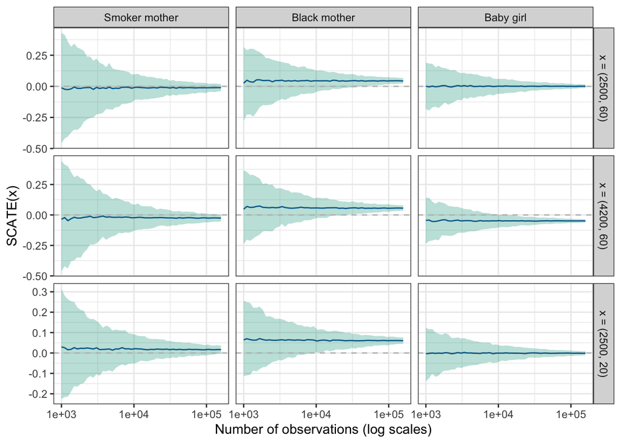

```r
cate_sim_df %>%
  mutate(
    name = factor(idx, levels = c(1:3),
                  labels = c("x = (2500, 60)", "x = (4200, 60)", "x = (2500, 20)")),
    treatment_name = factor(treatment_name, levels = c("cig_rec", "black_mother", "sex"),
                            labels = c("Smoker mother", "Black mother", "Baby girl"))
  ) %>%
ggplot(data = .,
       mapping = aes(x = size, y = mean)) +
  geom_ribbon(mapping = aes(ymin = q1_05, ymax = q1_95), fill = couleur1, alpha = .3) +
  geom_hline(yintercept = 0, colour = "grey", linetype = "dashed") +
  geom_line(colour = couleur3) +
  facet_grid(name~treatment_name, scales = "free") +
  scale_x_log10() +
  labs(x = "Number of observations (log scales)", y = "SCATE(x)") +
  theme_bw()
```

Equivalently, we can create beautiful plots with {graphics}.

**\(T\): Smoker mother**

Figure 2. Estimation of the Mutatis Mutandis CATE for $\boldsymbol{x}=(2500,60)$, using a GAM model with Gaussian transport, on n observations when Y=1 (non-natural delivery) and X is the weight of the newborn infant and the weight gain of the mother when T indicates whether the mother is a smoker or not.

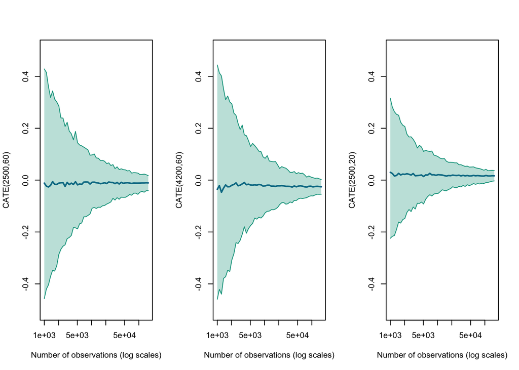

```r
cate_sim_smoker_df <-
  bind_rows(cate_sim_smoker) %>%
  group_by(idx, size) %>%
  summarise(
    q1_05 = quantile(SCATE, probs = .05),
    mean = mean(SCATE),
    q1_95 = quantile(SCATE, probs = .95),
  )

par(mfrow = c(1,3))
CATE <- cate_sim_smoker_df %>% filter(idx == 1)
plot(x = CATE$size, y = CATE$mean,
     col=couleur3, lwd=2,
     type="l", ylim=c(-.5,.5),
     log="x",
     xlab="Number of observations (log scales)",
     ylab="CATE(2500,60)")
polygon(c(CATE$size, rev(CATE$size)), c(CATE$q1_05, rev(CATE$q1_95)),
        col=scales::alpha(couleur1,.3),border=NA)
lines(CATE$size, CATE$q1_05, col = couleur1)
lines(CATE$size, CATE$q1_95, col = couleur1)

CATE <- cate_sim_smoker_df %>% filter(idx == 2)
plot(x = CATE$size, y = CATE$mean,
     col=couleur3, lwd=2,
     type = "l", ylim = c(-.5,.5), log = "x",
     xlab = "Number of observations (log scales)",
     ylab = "CATE(4200,60)")
polygon(c(CATE$size, rev(CATE$size)), c(CATE$q1_05, rev(CATE$q1_95)),
        col = scales::alpha(couleur1,.3), border = NA)
lines(CATE$size, CATE$q1_05, col = couleur1)
lines(CATE$size, CATE$q1_95, col = couleur1)

CATE <- cate_sim_smoker_df %>% filter(idx == 3)
plot(x = CATE$size, y = CATE$mean,
     col = couleur3, lwd=2,
     type = "l",ylim=c(-.5,.5),log="x",
     xlab = "Number of observations (log scales)",
     ylab = "CATE(2500,20)")
polygon(c(CATE$size, rev(CATE$size)), c(CATE$q1_05, rev(CATE$q1_95)),
        col = scales::alpha(couleur1,.3), border = NA)
lines(CATE$size, CATE$q1_05, col = couleur1)
lines(CATE$size, CATE$q1_95, col = couleur1)
```

**\(T\): Black mother**

Figure 3. Estimation of the Mutatis Mutandis CATE for $\boldsymbol{x}=(2500,60)$, using a GAM model with Gaussian transport, on n observations when Y=1 (non-natural delivery) and X is the weight of the newborn infant and the weight gain of the mother when T indicates whether the mother is Black or not.

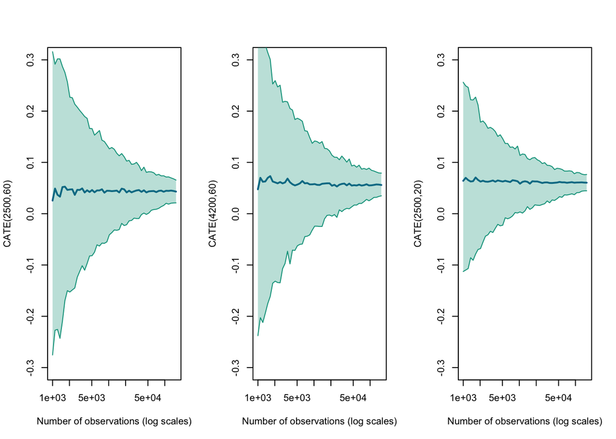

```r
cate_sim_blackm_df <-
  bind_rows(cate_sim_blackm) %>%
  group_by(idx, size) %>%
  summarise(
    q1_05 = quantile(SCATE, probs = .05),
    mean = mean(SCATE),
    q1_95 = quantile(SCATE, probs = .95),
  )

par(mfrow = c(1,3))
CATE <- cate_sim_blackm_df %>% filter(idx == 1)
plot(x = CATE$size, y = CATE$mean,
     col=couleur3, lwd=2,
     type = "l", ylim = c(-.3,.3), log = "x",
     xlab="Number of observations (log scales)",
     ylab="CATE(2500,60)")
polygon(c(CATE$size, rev(CATE$size)), c(CATE$q1_05, rev(CATE$q1_95)),
        col=scales::alpha(couleur1,.3),border=NA)
lines(CATE$size, CATE$q1_05, col = couleur1)
lines(CATE$size, CATE$q1_95, col = couleur1)

CATE <- cate_sim_blackm_df %>% filter(idx == 2)
plot(x = CATE$size, y = CATE$mean,
     col=couleur3, lwd=2,
     type = "l", ylim = c(-.3,.3), log = "x",
     xlab = "Number of observations (log scales)",
     ylab = "CATE(4200,60)")
polygon(c(CATE$size, rev(CATE$size)), c(CATE$q1_05, rev(CATE$q1_95)),
        col = scales::alpha(couleur1,.3), border = NA)
lines(CATE$size, CATE$q1_05, col = couleur1)
lines(CATE$size, CATE$q1_95, col = couleur1)

CATE <- cate_sim_blackm_df %>% filter(idx == 3)
plot(x = CATE$size, y = CATE$mean,
     col = couleur3, lwd=2,
     type = "l", ylim = c(-.3,.3), log = "x",
     xlab = "Number of observations (log scales)",
     ylab = "CATE(2500,20)")
polygon(c(CATE$size, rev(CATE$size)), c(CATE$q1_05, rev(CATE$q1_95)),
        col = scales::alpha(couleur1,.3), border = NA)
lines(CATE$size, CATE$q1_05, col = couleur1)
lines(CATE$size, CATE$q1_95, col = couleur1)
```

**\(T\): Baby girl**

Figure 4. Estimation of the Mutatis Mutandis CATE for $\boldsymbol{x}=(2500,60)$, using a GAM model with Gaussian transport, on n observations when Y=1 (non-natural delivery) and X is the weight of the newborn infant and the weight gain of the mother when T indicates whether the newborn is a girl.

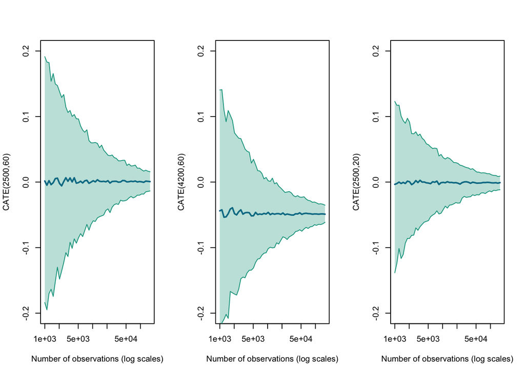

```r
cate_sim_sex_df <-
  bind_rows(cate_sim_sex) %>%
  group_by(idx, size) %>%
  summarise(
    q1_05 = quantile(SCATE, probs = .05),
    mean = mean(SCATE),
    q1_95 = quantile(SCATE, probs = .95),
  )

par(mfrow = c(1,3))
CATE <- cate_sim_sex_df %>% filter(idx == 1)
plot(x = CATE$size, y = CATE$mean,
     col=couleur3, lwd=2,
     type="l", ylim=c(-.2,.2), log="x",
     xlab="Number of observations (log scales)",
     ylab="CATE(2500,60)")
polygon(c(CATE$size, rev(CATE$size)), c(CATE$q1_05, rev(CATE$q1_95)),
        col=scales::alpha(couleur1,.3),border=NA)
lines(CATE$size, CATE$q1_05, col = couleur1)
lines(CATE$size, CATE$q1_95, col = couleur1)

CATE <- cate_sim_sex_df %>% filter(idx == 2)
plot(x = CATE$size, y = CATE$mean,
     col=couleur3, lwd=2,
     type="l", ylim=c(-.2,.2), log="x",
     xlab = "Number of observations (log scales)",
     ylab = "CATE(4200,60)")
polygon(c(CATE$size, rev(CATE$size)), c(CATE$q1_05, rev(CATE$q1_95)),
        col = scales::alpha(couleur1,.3), border = NA)
lines(CATE$size, CATE$q1_05, col = couleur1)
lines(CATE$size, CATE$q1_95, col = couleur1)

CATE <- cate_sim_sex_df %>% filter(idx == 3)
plot(x = CATE$size, y = CATE$mean,
     col = couleur3, lwd=2,
     type="l", ylim=c(-.2,.2), log="x",
     xlab = "Number of observations (log scales)",
     ylab = "CATE(2500,20)")
polygon(c(CATE$size, rev(CATE$size)), c(CATE$q1_05, rev(CATE$q1_95)),
        col = scales::alpha(couleur1,.3), border = NA)
lines(CATE$size, CATE$q1_05, col = couleur1)
lines(CATE$size, CATE$q1_95, col = couleur1)
```